# Exercícios Aula 12 - Análise de texto

Beatriz Milz

26/06/2020

```r
library(tidyverse)
library(nycflights13)
library(pdftools)
#install.packages("wordcloud")
#install.packages("tm")
library(wordcloud)
library(tm)
library(wordcloud2)
#install.packages("gutenbergr")
library(gutenbergr)
library(tidytext)
#install.packages("textstem")
library(textstem)
#install.packages("lexiconPT")
library(lexiconPT)
library(zoo)
#install.packages("topicmodels")
library(topicmodels)
library(broom)
#devtools::install_github("abjur/abjutils")
library(abjutils)
```

## Exercício 1: Trabalhando com Strings

1. No banco de dados airlines do pacote nycflights13, qual porcentagem dos nomes das companhias aéreas contém a palavra ‘Airlines’ e qual porcentagem contém a palavra ‘Airways’?

```r
nycflights13::airlines %>% mutate(
  contem_airlines = stringr::str_detect(name, "Airlines"),
  contem_airways = stringr::str_detect(name, "Airways")
)   %>% summarize(
  porcentagem_airlines = sum(contem_airlines) / nrow(.) * 100,
  porcentagem_airways = sum(contem_airways)*100 /
    nrow(.),
)
```

| porcentagem_airlines | porcentagem_airways |
| --- | --- |
| 50 | 18.75 |

2. No mesmo banco, Substitua os nomes das companhias aéreas que contém ‘Inc.’ com ‘Incorporated’, e eles que contém ‘Co.’ com ‘Company’. (Observe que ‘.’ é um caracter especial, então tem que buscar ele com ‘\.’).

```r
nycflights13::airlines %>% mutate(novo_nome = stringr::str_replace_all(name, "Inc\\.", "Incorporated"),
                                  novo_nome = stringr::str_replace_all(novo_nome, "Co\\.", "Company"),
                                  )
```

| carrier | name | novo_nome |
| --- | --- | --- |
| 9E | Endeavor Air Inc. | Endeavor Air Incorporated |
| AA | American Airlines Inc. | American Airlines Incorporated |
| AS | Alaska Airlines Inc. | Alaska Airlines Incorporated |
| B6 | JetBlue Airways | JetBlue Airways |
| DL | Delta Air Lines Inc. | Delta Air Lines Incorporated |
| EV | ExpressJet Airlines Inc. | ExpressJet Airlines Incorporated |
| F9 | Frontier Airlines Inc. | Frontier Airlines Incorporated |
| FL | AirTran Airways Corporation | AirTran Airways Corporation |
| HA | Hawaiian Airlines Inc. | Hawaiian Airlines Incorporated |
| MQ | Envoy Air | Envoy Air |

[output cut: 6 more lines]

3. Gere um nome curto para cada companhia aérea, refletindo apenas a primeira palavra do nome.

```r
nycflights13::airlines %>% mutate(nome_curto = stringr::str_split(name, " ")) %>%
  mutate(nome_parcial_primeiro=map_chr(nome_curto, 1))
```

| carrier | name | nome_curto | nome_parcial_primeiro |
| --- | --- | --- | --- |
| 9E | Endeavor Air Inc. |  | Endeavor |
| AA | American Airlines Inc. |  | American |
| AS | Alaska Airlines Inc. |  | Alaska |
| B6 | JetBlue Airways |  | JetBlue |
| DL | Delta Air Lines Inc. |  | Delta |
| EV | ExpressJet Airlines Inc. |  | ExpressJet |
| F9 | Frontier Airlines Inc. |  | Frontier |
| FL | AirTran Airways Corporation |  | AirTran |
| HA | Hawaiian Airlines Inc. |  | Hawaiian |
| MQ | Envoy Air |  | Envoy |

[output cut: 6 more lines]

4. Crie um ‘wordcloud’ dos nomes das companhias aéreas.

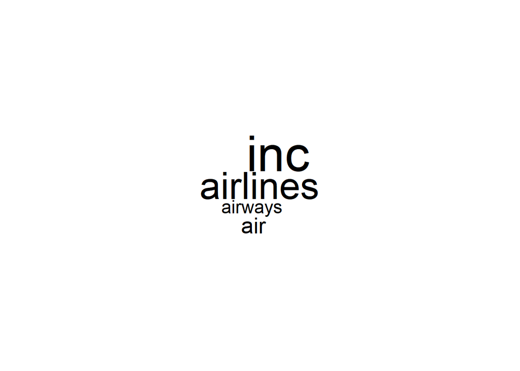

```r
wordcloud(airlines$name)
```

## Exercício 2: Analisando um Documento

1. Escolhe um livro da sua preferência no site de Projeto Gutenberg, e abre ele em R usando o código do projeto.

```r
camoes <- gutenberg_download(3333) %>%
  mutate(text = iconv(text, from = "latin1", to = "UTF-8")) %>%
  select(-gutenberg_id) %>%
  rownames_to_column("linha")
```

2. ‘Tokenizar’ o seu livro em palavras, tirando a puntuação, os números, os stopwords, virando as caracteres em minúsculo, e as palavras em seus stems (raízes).

```r
camoes_token <- camoes %>%
  unnest_tokens(palavra, text, strip_numeric = TRUE) %>%
  mutate(palavra_sem_acento = abjutils::rm_accent(palavra))  %>% mutate(stem =                                                         stem_words(palavra, language = "pt"))


stopwords <- get_stopwords(language="pt") %>%
rename(palavra=word) %>% add_row(palavra=c("é", "de", "e", "o"), lexicon="pessoal")



camoes_sem_stop <- camoes_token %>% anti_join(stopwords, by="palavra")

camoes_sem_stop %>% group_by(palavra_sem_acento) %>%  tally() %>% arrange(-n) %>% top_n(10)
```

| palavra_sem_acento | n |
| --- | --- |
| gente | 230 |
| terra | 222 |
| tao | 210 |
| rei | 204 |
| mar | 188 |
| onde | 177 |
| grande | 138 |
| tanto | 132 |
| ali | 103 |
| assim | 102 |

[output cut: 1 more lines]

3. Identifique os dez stems mais frequentes no seu livro.

```r
camoes_sem_stop %>% group_by(stem) %>%  tally() %>% arrange(-n) %>% top_n(10)
```

| stem | n |
| --- | --- |
| gent | 285 |
| terr | 271 |
| tod | 244 |
| mar | 228 |
| tã | 210 |
| outr | 207 |
| rei | 204 |
| tant | 203 |
| grand | 187 |
| onde | 180 |

4. Aplique uma análise de sentimento ao texto para identificar as linhas mais otimistas e mais pessimistas do texto.

```r
sentimento <- oplexicon_v3.0 %>%
  mutate(palavra_sem_acento = abjutils::rm_accent(term)) %>%
  select(palavra_sem_acento, polarity)

camoes_sentimento <- camoes_sem_stop %>% left_join(sentimento)


camoes_sentimento  %>% mutate(linha=as.numeric(linha)) %>%
  group_by(linha) %>%
  summarize(sum_polarity = sum(polarity, na.rm=T)) %>%
  arrange(-sum_polarity) %>%
  slice(1, n())
```

| linha | sum_polarity |
| --- | --- |
| 7891 | 5 |
| 7999 | -4 |

```r
camoes %>% filter(linha==7891) %>% pull(text) #Linha mais otimista
```

```
## [1] "Digno feito de ser no mundo eterno,"
```

```r
camoes %>% filter(linha==7999) %>% pull(text) #Linha mais pessimista
```

```
## [1] "Vai-se espantado o atónito agoureiro"
```

## Exercício 3: Comparando Documentos

1. Copiar-colar um texto que você mesmo escreveu de pelo menos um parágrafo e salve ele dentro de um tibble em R.

```r
texto <- tibble(texto = "Meu nome é Beatriz, e meu pronome é “ela”. Atualmente sou doutoranda em Ciência Ambiental (PROCAM/IEE/USP) na Universidade de São Paulo. Sou pesquisadora no Projeto Temático FAPESP MacroAmb - Governança ambiental da Macrometrópole Paulista face à variabilidade climática. Faço parte voluntariamente da equipe da Secretaria Executiva da Revista Ambiente & Sociedade, uma revista científica Brasileira que é referência em estudos interdisciplinares sobre ambiente e sociedade. Comecei a aprender R em agosto de 2018, e recentemente comecei a aprender Python. Sou co-organizadora da R-Ladies São Paulo, uma comunidade que tem como objetivo promover a diversidade de gênero na comunidade da linguagem R. Também participo da comunidade PyLadies São Paulo, que tem como objetivo unir mulheres em torno do mundo da programação, especialmente usando Python. Sou instrutora da Carpentries, um projeto que tem como missão ensinar habilidades de ciência de dados para pessoas pesquisadoras.")
```

2. ‘Tokenizar’ o seu texto em palavras, tirando a puntuação, os números, os stopwords, virando as caracteres em minúsculo, e as palavras em seus raízes (stems).

```r
texto_token <- texto %>%
  unnest_tokens(palavra, texto, strip_numeric = TRUE) %>%
  mutate(palavra_sem_acento = abjutils::rm_accent(palavra))  %>% mutate(stem = stem_words(palavra, language = "pt"))%>% anti_join(stopwords, by="palavra")

head(texto_token)
```

| palavra | palavra_sem_acento | stem |
| --- | --- | --- |
| nome | nome | nom |
| beatriz | beatriz | beatriz |
| pronome | pronome | pronom |
| atualmente | atualmente | atual |
| doutoranda | doutoranda | doutorand |
| ciência | ciencia | ciênc |

3. Junte dois textos tokenizados em um tibble com uma coluna que diferencia o documento e uma coluna que conta a frequência de cada palavra: (i) o texto seu que você identificou acima em questão 1, e (ii) o livro que você usou em exercício 2.

```r
meu_texto_tally <- texto_token %>%
  group_by(palavra_sem_acento) %>%
  tally() %>%
  mutate(document = "Meu texto")

camoes_tally <- camoes_sem_stop %>%
  group_by(palavra_sem_acento) %>%
  tally() %>%
  mutate(document = "Camões")

df_textos <- bind_rows(meu_texto_tally, camoes_tally)
```

4. Calcule a medida ‘tf_idf’ para identificar as 5 palavras mais distintas de cada documento. Em qual sentido o seu documento é diferente do livro?

```r
textos_idf <- df_textos %>% bind_tf_idf(palavra_sem_acento, document, n)


textos_idf %>%
  group_by(document) %>%
  top_n(5, tf_idf)
```

| palavra_sem_acento | n | document | tf | idf | tf_idf |
| --- | --- | --- | --- | --- | --- |
| ambiental | 2 | Meu texto | 0.023255814 | 0.6931472 | 0.016119702 |
| ambiente | 2 | Meu texto | 0.023255814 | 0.6931472 | 0.016119702 |
| aprender | 2 | Meu texto | 0.023255814 | 0.6931472 | 0.016119702 |
| comunidade | 3 | Meu texto | 0.034883721 | 0.6931472 | 0.024179553 |
| objetivo | 2 | Meu texto | 0.023255814 | 0.6931472 | 0.016119702 |
| projeto | 2 | Meu texto | 0.023255814 | 0.6931472 | 0.016119702 |
| python | 2 | Meu texto | 0.023255814 | 0.6931472 | 0.016119702 |
| r | 3 | Meu texto | 0.034883721 | 0.6931472 | 0.024179553 |
| revista | 2 | Meu texto | 0.023255814 | 0.6931472 | 0.016119702 |
| sociedade | 2 | Meu texto | 0.023255814 | 0.6931472 | 0.016119702 |

[output cut: 5 more lines]